# Урок 5. Библиотека SEABORN. Визуализация и аналитика

**ВАРИАНТ 6 - Даренский Павел, 932201**

**ЗАДАНИЕ**

1. Ваш код должен быть снабжен комментариями – преподаватель не должен догадываться – что имелось ввиду.
2. Выберите датасет из встроенного в seaborn для дальнейшего анализ (опционально – можно взять любые открытые данные, используя любой открытый репозиторий).
3. Найдите описание датасета (о чем данные, где взят и т.п.) и данных (описание – что характеризует, тип) и добавьте в отчет. Изучение предметной области – немаловажный шаг для аналитика данных.
4. Проверьте – есть ли отсутствующие данные, если есть – удалите.
5. Используя различного рода визуализации проведите исследование данных: закономерности, зависимости, распределения. Снабдите каждый график необходимыми подписями (заголовок, оси, легенда и т.п.), выберите подходящую цветовую гамму. В качестве образца можно взять данный Урок.
6. По желанию можно добавить графики и диаграммы, не описанные в Уроке.
7. По каждому графику должен быть вывод – что исследовано и что получено.
8. Сделайте общий вывод по работе.

Данные взяты с https://www.kaggle.com/code/payamamanat/imdb-movies

**Описание:**

Набор данных IMDb — это совокупность данных, собранных и предоставленных IMDb (Internet Movie Database), одной из самых полных онлайн-баз данных о фильмах, телешоу, актёрах и съёмочных группах. IMDb — это широко используемая платформа для доступа к информации о фильмах и телепрограммах, включая такие сведения, как актёрский состав и съёмочная группа, рейтинги и отзывы пользователей, краткое содержание, интересные факты и многое другое.

Размерность данных : 9957 образцов и 9 признаков.

1. title : название фильма;
2. year : год выпуска (также объединяются серии);
3. certificate : у каждого фильма есть специальная лицензионная компания (в этой колонке указаны названия компаний для каждого фильма);
4. duration : продолжительность каждого фильма;
5. genre : жанры фильма (романтические фильмы, фильмы ужасов и т.д.);
6. rating : IMDB выставляет определенную оценку каждому фильму;
7. description : краткое содержание фильма;
8. stars : актеры и актрисы;
9. votes : просмотры и мнения людей о фильме.

# Подключение необходимых библиотек и загрузка данных

```python
# подключение необходимых библиотек
import matplotlib.pyplot as plt
from matplotlib.font_manager import FontProperties
import numpy as np
from matplotlib.ticker import AutoMinorLocator
import pandas as pd
import seaborn as sns
import plotly.express as px
import re
```

```python
# подключение к google disk
from google.colab import drive
drive.mount('/content/drive')
```

```python
# загрузка данных с диска
file_path = "/content/drive/MyDrive/TSU/SEMESTR_6/MultiDataVisualization/LW5/IMBD.csv"
data = pd.read_csv(file_path, sep=',')
```

# Предобработка данных

```python
# выведем 10 случайно выбранных образцов из набора данных
data.sample(10)
```

|  | title | year | certificate | duration | genre | rating | description | stars | votes |
| --- | --- | --- | --- | --- | --- | --- | --- | --- | --- |
| 179 | JoJo's Bizarre Adventure | (2012– ) | TV-14 | 30 min | Animation, Action, Adventure | 8.4 | The story of the Joestar family, who are posse... | ['David Vincent, ', 'Matthew Mercer, ', 'Daisu... | 22,677 |
| 7350 | Croaker | (2013) | Not Rated | 71 min | Horror | 7.3 | Florian Sirko and his one-time love, Macy Patt... | ['Fred Terling', '\| ', ' Stars:', 'Martin P... | 74 |
| 2371 | An Affair to Die For | (2019) | TV-MA | 82 min | Horror, Thriller | 4.8 | A secret rendezvous. A man cheats on his wife.... | ['Víctor Garcia', '\| ', ' Stars:', 'Claire ... | 2,129 |
| 7341 | Virunga: Gorillas in Peril | (2015 TV Movie) | NaN | 28 min | Documentary | 6.5 | A behind the scenes look at the Academy Award ... | ['Lisa Kors', '\| ', ' Stars:', "Soledad O'B... | 32 |
| 7178 | Flip a Coin | (2004) | Not Rated | 95 min | Comedy | 6.1 | CASPER and PHILIP two friends in their mid twe... | ['David Flamholc', '\| ', ' Stars:', 'Max Fr... | 52 |
| 6712 | Michael Che Matters | (2016 TV Special) | TV-MA | 61 min | Comedy | 7.2 | Jesus, Guns, Black Lives Matter. White girls d... | ['Oz Rodriguez', '\| ', ' Stars:', 'Michael ... | 2,679 |
| 2258 | Frequency | (2016–2017) | TV-MA | 42 min | Drama, Fantasy, Mystery | 7.4 | A police detective in 2016 discovers that she ... | ['Peyton List, ', 'Riley Smith, ', 'Devin Kell... | 13,862 |
| 1677 | We Summon the Darkness | (2019) | R | 91 min | Horror, Music, Thriller | 5.2 | Three best friends embark on a road trip to a ... | ['Marc Meyers', '\| ', ' Stars:', 'Alexandra... | 10,714 |
| 9098 | Hotel Del Luna | (2019) | NaN | 74 min | Action, Comedy, Drama | 8.0 | The old tree shows signs of life, alarming Man... | ['Choong Hwan Oh', '\| ', ' Stars:', 'Ji-eun... | 119 |
| 4449 | The Bleeding Edge | (2018) | TV-14 | 99 min | Documentary | 7.6 | A look at the unforeseen consequences of advan... | ['Kirby Dick', '\| ', ' Stars:', 'Robert Bri... | 2,765 |

```python
# Выведем информацию о наборе данных
data.info()
```

```
<class 'pandas.core.frame.DataFrame'>
RangeIndex: 9957 entries, 0 to 9956
Data columns (total 9 columns):
 #   Column       Non-Null Count  Dtype
---  ------       --------------  -----
 0   title        9957 non-null   object
 1   year         9430 non-null   object
 2   certificate  6504 non-null   object
 3   duration     7921 non-null   object
 4   genre        9884 non-null   object
 5   rating       8784 non-null   float64
 6   description  9957 non-null   object
 7   stars        9957 non-null   object
 8   votes        8784 non-null   object
dtypes: float64(1), object(8)
memory usage: 700.2+ KB
```

Здесь имеется 8 категориальных признаков и 1 числовой признак - rating. Пропущенных значений нет только у трёх столбцов - title, description, stars.

```python
# Подсчитать количество пропущенных значений в каждом поле также можно с помощью следующей функции
missing_value_cnt = data.isnull().sum()
missing_value_cnt
```

|  | 0 |
| --- | --- |
| title | 0 |
| year | 527 |
| certificate | 3453 |
| duration | 2036 |
| genre | 73 |
| rating | 1173 |
| description | 0 |
| stars | 0 |
| votes | 1173 |

**dtype:** int64

```python
# Для дальнейшей работы признак certificate заполним модой, признаки duration (значение будет в минутах, целое), rating, votes (будет целое) заполним средним значением

# 1. Признак 'certificate' (категориальный) заполняем самым частым значением (модой)
data['certificate'] = data['certificate'].fillna(data['certificate'].mode()[0])

# 2. Признак 'duration' (строка вида "85 min") нужно сначала очистить и привести к числу
#    Удаляем ' min' и преобразуем к типу int
data['duration'] = data['duration'].str.replace(' min', '')
data['duration'] = pd.to_numeric(data['duration'], errors='coerce')  # Преобразуем с заменой некорректных значений на NaN

# Теперь можно заполнить пропуски в 'duration' средним значением (округляем до целого)
data['duration'] = data['duration'].fillna(round(data['duration'].mean()))
data['duration'] = data['duration'].astype(int)

# 3. Признак 'rating' (числовой) заполняем средним значением
data['rating'] = data['rating'].fillna(data['rating'].mean())

# 4. Признак 'votes' (строка с запятыми, например "4,202") нужно сначала убрать запятые, потом привести к числу
data['votes'] = data['votes'].str.replace(',', '')
data['votes'] = pd.to_numeric(data['votes'], errors='coerce')

# Заполняем пропуски в 'votes' средним значением (округляем до целого)
data['votes'] = data['votes'].fillna(round(data['votes'].mean()))
data['votes'] = data['votes'].astype(int)

# Проверим информацию о наборе данных после предобработки
data.info()
```

```
<class 'pandas.core.frame.DataFrame'>
RangeIndex: 9957 entries, 0 to 9956
Data columns (total 9 columns):
 #   Column       Non-Null Count  Dtype
---  ------       --------------  -----
 0   title        9957 non-null   object
 1   year         9430 non-null   object
 2   certificate  9957 non-null   object
 3   duration     9957 non-null   int64
 4   genre        9884 non-null   object
 5   rating       9957 non-null   float64
 6   description  9957 non-null   object
 7   stars        9957 non-null   object
 8   votes        9957 non-null   int64
dtypes: float64(1), int64(2), object(6)
memory usage: 700.2+ KB
```

Теперь у нас 6 категориальных признаков, 1 числовой (вещественный который и был) и 2 признака с целочисленными значениями: duration, votes.

```python
# посмотрим что стало с пропусками
missing_value_cnt = data.isnull().sum()
missing_value_cnt
```

|  | 0 |
| --- | --- |
| title | 0 |
| year | 527 |
| certificate | 0 |
| duration | 0 |
| genre | 73 |
| rating | 0 |
| description | 0 |
| stars | 0 |
| votes | 0 |

**dtype:** int64

```python
# Распределение по атрибуту certificate - посмотрим - сколько каких сертификатов содержит датасет
print(data.groupby('certificate').size())
```

```
certificate
12              1
Approved       26
E10+            1
G              43
M               1
MA-17           1
NC-17           4
Not Rated     467
PG            159
PG-13         282
Passed          6
R             472
TV-14        1209
TV-G          151
TV-MA        5973
TV-PG         543
TV-Y          175
TV-Y7         349
TV-Y7-FV       31
Unrated        63
dtype: int64
```

Как видно данные несбалансированы по признаку - сертификат, TV-MA самый распространненый (5973), остальных где-то сотни, где-то тысячи, а где то и вовсе единицы и десятки.

```python
# построим сводную таблицу (summary statistics) по всем столбцам датафрейма
data.describe(include='all')
```

|  | title | year | certificate | duration | genre | rating | description | stars | votes |
| --- | --- | --- | --- | --- | --- | --- | --- | --- | --- |
| count | 9957 | 9430 | 9957 | 9957.000000 | 9884 | 9957.000000 | 9957 | 9957 | 9.957000e+03 |
| unique | 7912 | 498 | 20 | NaN | 569 | NaN | 9433 | 8615 | NaN |
| top | Top Gear | (2020) | TV-MA | NaN | Comedy | NaN | Add a Plot | [] | NaN |
| freq | 92 | 663 | 5973 | NaN | 859 | NaN | 434 | 403 | NaN |
| mean | NaN | NaN | NaN | 73.818319 | NaN | 6.764515 | NaN | NaN | 1.952317e+04 |
| std | NaN | NaN | NaN | 44.846923 | NaN | 1.141033 | NaN | NaN | 8.225763e+04 |
| min | NaN | NaN | NaN | 1.000000 | NaN | 1.700000 | NaN | NaN | 5.000000e+00 |
| 25% | NaN | NaN | NaN | 46.000000 | NaN | 6.200000 | NaN | NaN | 3.580000e+02 |
| 50% | NaN | NaN | NaN | 74.000000 | NaN | 6.764515 | NaN | NaN | 1.745000e+03 |
| 75% | NaN | NaN | NaN | 93.000000 | NaN | 7.500000 | NaN | NaN | 1.506200e+04 |
| max | NaN | NaN | NaN | 990.000000 | NaN | 9.900000 | NaN | NaN | 1.844075e+06 |

Здесь можно получить различную статистическую информацию по каждому признаку (количество уникальных значений, моду, среднее и т.д.).

# Исследование данных с помощью визуализации

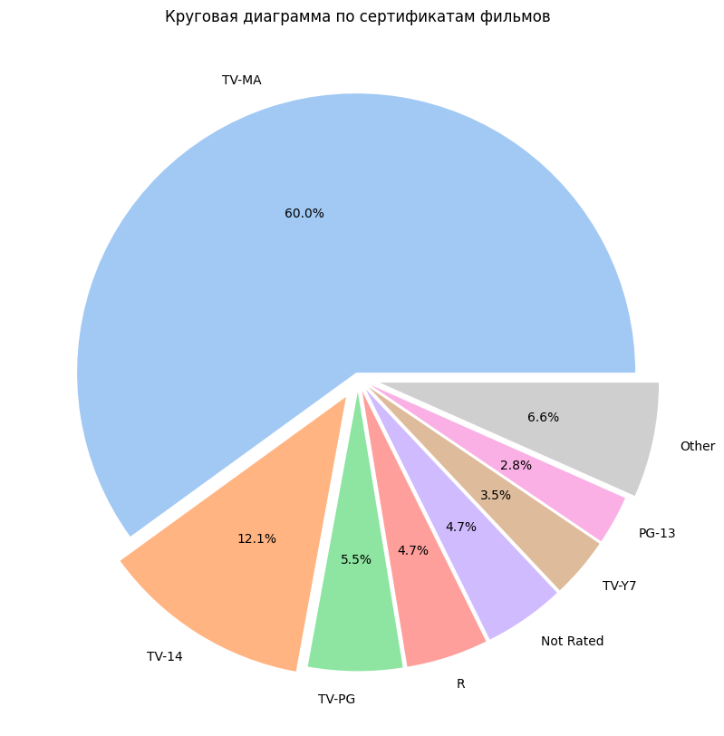

```python
counts = data['certificate'].value_counts()

# Порог для объединения фильмов в категорию "Другие" с маленькими частотами по сертификатам
limit = 200

# Создаём новые серии
counts_reduced = counts[counts >= limit]
other_sum = counts[counts < limit].sum()

# Добавляем "Other"
counts_reduced['Other'] = other_sum

explode = [0.02, 0.08, 0.05, 0.05, 0.05, 0.05, 0.05, 0.08]

colors = sns.color_palette('pastel')

counts_reduced.plot.pie(
    explode=explode,
    autopct='%1.1f%%',
    colors=colors[:len(counts_reduced)],
    figsize=(10,10)
)

plt.title('Круговая диаграмма по сертификатам фильмов')
plt.ylabel('')
plt.show()
```

Пояснения к графику аналогичны выше сказанным - о несбалансированности фильмов по сертификатам.

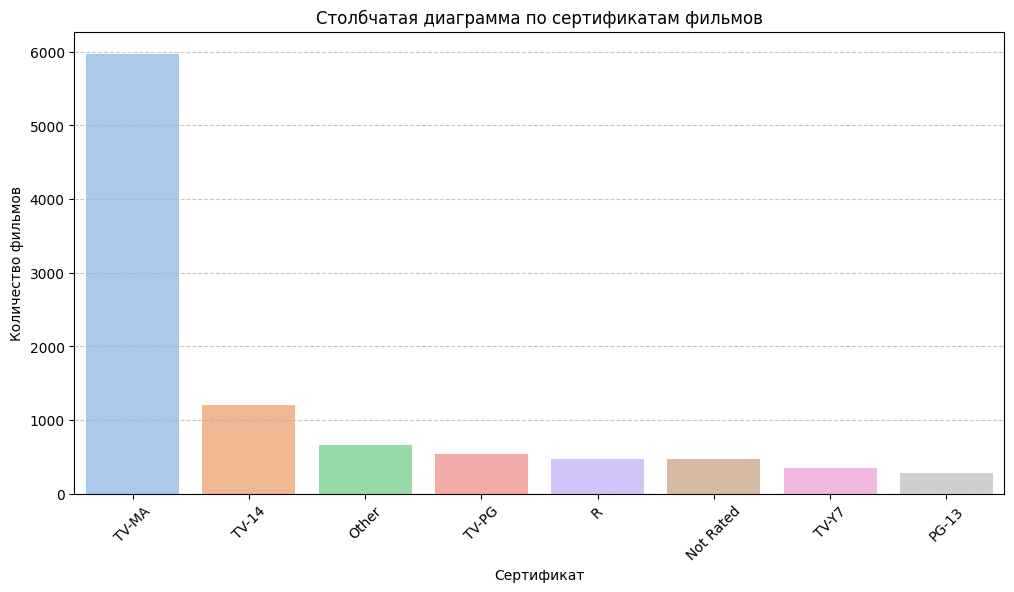

```python
# Сначала пересоздадим колонку certificate с учетом объединения редких категорий в "Другие"
limit = 200
counts = data['certificate'].value_counts()
rare_certs = counts[counts < limit].index

# Создадим новую колонку, где редкие сертификаты заменяются на 'Other'
data['certificate_reduced'] = data['certificate'].apply(lambda x: x if x not in rare_certs else 'Other')

plt.figure(figsize=(12,6))
sns.countplot(
    x='certificate_reduced',
    data=data,
    order=data['certificate_reduced'].value_counts().index,  # от большего к меньшему
    palette='pastel'
)

plt.title('Столбчатая диаграмма по сертификатам фильмов')
plt.xlabel('Сертификат')
plt.ylabel('Количество фильмов')
plt.xticks(rotation=45)
plt.grid(axis='y', linestyle='--', alpha=0.7)
plt.show()
```

Пояснения к графику аналогичны выше сказанным - о несбалансированности фильмов по сертификатам.

```python
# Удаляем временный ранее созданный столбец
data.drop(columns=['certificate_reduced'], inplace=True)
data.shape
```

```
(9957, 9)
```

```python
# Заполняем пропуски строкой 'NAN'
data.fillna('NAN', inplace=True)

# Оставляем только цифры, тире и 'NAN', всё остальное заменяем на пробел
data['year'] = data['year'].apply(lambda x: re.sub('[^0-9NAN-]', ' ', x))

# Убираем лишние пробелы
data['year'] = data['year'].apply(lambda x: re.sub(r'[ ]+', ' ', x))

# Смотрим результат
data['year'].unique()
```

```
array([' 2018 ', ' 2016 ', ' 2015 2022 ', ' 2022 ', ' 2013 ',
       ' 2008 2013 ', ' 2010 2022 ', ' 2013 2022 ', ' 2021 ', ' 2001 ',
       ' 2005 ', ' 2005 2020 ', ' 2011 ', ' 2003 ', ' 1994 2004 ',
       ' 2011 2021 ', ' 2009 2020 ', ' 2017 2022 ', ' 2011 2019 ',
       ' 2013 2020 ', ' 2019 ', ' 1989 1998 ', ' 2016 2021 ',
       ' 2019 2023 ', ' 2013 2021 ', ' 2000 2007 ', ' 2014 ', ' 2015 ',
       ' 2020 2023 ', ' 2013 2023 ', ' 2020 2022 ', ' 2017 2020 ',
       ' 2009 2017 ', ' 1999 ', ' 2016 2022 ', ' 2005 2014 ',
       ' 2009 2015 ', ' 2015 2018 ', ' 2010 ', ' 2015 2020 ', ' 2002 ',
       ' 2000 ', ' 2012 ', ' 2017 ', ' 2008 2014 ', ' 2007 2015 ',
       ' 2014 2023 ', ' 2009 ', ' 2015 2019 ', ' 1998 2006 ', ' 2020 ',
       ' 1997 ', ' 2010 2017 ', ' 2006 2013 ', ' 2011 2018 ',
       ' 2010 2015 ', ' 2001 2017 ', ' 1987 1994 ', ' 2014 2020 ',
       ' 2017 2021 ', ' 2013 2019 ', ' 1993 ', ' 2005 2017 ', ' 1975 ',
       ' 2010 2013 ', ' 1995 ', ' 2017 2019 ', ' 1984 1996 ',
       ' 2000 2015 ', ' 2003 2019 ', ' 2007 ', ' 2015 2017 ',
       ' 2011 2020 ', ' 2004 2022 ', ' 2010 2020 ', ' 1966 1969 ',
       ' 2008 ', ' 2009 2016 ', ' 2019 2022 ', ' 1976 ', ' 2011 2017 ',
       ' 1994 ', ' 2012 2020 ', ' 2016 2020 ', ' 1982 1993 ',
       ' 2012 2021 ', ' 2006 ', ' 2008 2020 ', ' 1993 1999 ',
       ' 2013 2018 ', ' 2014 2019 ', ' 2007 2012 ', ' 2007 2010 ',
       ' 1990 1991 ', ' 2005 2008 ', ' 2013 2015 ', ' 1995 2001 ',
       ' 2018 2021 ', ' 2012 2017 ', ' 2009 2014 ', ' 2018 2022 ',
       ' 2014 2017 ', ' 2012 2019 ', ' 1978 ', ' 2013 2016 ', ' 1968 ',
       ' 2002 2007 ', ' 2013 2017 ', ' 2014 2018 ', ' 2010 2018 ',
       ' 2016 2019 ', ' 2011 2014 ', ' 1989 ', ' 2007 2013 ',
       ' 2004 2012 ', ' 2018 2020 ', ' 2015 2021 ', ' 2006 2007 ',
       ' 1994 1999 ', ' 2023 ', ' 2009 2010 ', ' 2017 2018 ',
       ' 2019 2021 ', ' 2001 2005 ', ' 2010 2019 ', 'NAN', ' 1999 2000 ',
       ' 2017 2023 ', ' 2014 2016 ', ' 2007 2014 ', ' 2004 ',
       ' 1998 2020 ', ' 2014 2022 ', ' 2011 2015 ', ' 2004 2013 ',
       ' 1980 ', ' 1971 ', ' 1987 1995 ', ' 2012 2018 ', ' 1984 ',
       ' 2016 2018 ', ' 2018 2019 ', ' 1991 ', ' 2019 2020 ',
       ' 2001 2018 ', ' 2009 2013 ', ' 1990 ', ' 1962 ', ' 1998 1999 ',
       ' 1996 2001 ', ' 1996 ', ' 1998 ', ' 1998 2003 ', ' 1990 1996 ',
       ' 1961 ', ' 1987 ', ' 1993 1996 ', ' 1979 ', ' 2016 2017 ',
       ' 2011 2016 ', ' 2012 2014 ', ' 2015 2016 ', ' ', ' 1995 1996 ',
       ' 2006 2008 ', ' 1988 ', ' 2010 2011 ', ' 2021 2022 ', ' 1960 ',
       ' 2013 2014 ', ' 2006 2011 ', ' 1983 ', ' 2006 2010 ',
       ' 1990 2000 ', ' 1994 2000 ', ' 1956 ', ' 1995 1998 ',
       ' 2014 2021 ', ' 2006 2021 ', ' 1969 ', ' 2002 2019 ',
       ' 2004 2019 ', ' 2012 2015 ', ' 2004 2018 ', ' 2009 2019 ',
       ' 2006 2009 ', ' 1975 1979 ', ' 1992 ', ' 1974 ', ' 2009 2011 ',
       ' 1941 ', ' 2003 2006 ', ' 2024 ', ' 1986 ', ' 2014 2015 ',
       ' 2012 2013 ', ' 2011 2022 ', ' 2020 2021 ', ' 2008 2009 ',
       ' 2010 2014 ', ' 1984 2021 ', ' 2003 2022 ', ' 2011 2012 ',
       ' 1969 1974 ', ' 1967 ', ' 1966 ', ' 2006 2012 ', ' 1958 ',
       ' 2012 2016 ', ' 1932 ', ' 1988 1999 ', ' 2000 2004 ',
       ' 2008 2010 ', ' 1992 1995 ', ' 2001 2004 ', ' 2011 2013 ',
       ' 1957 ', ' 1981 1989 ', ' 2002 2005 ', ' 2001 2002 ',
       ' 1992 2014 ', ' 2003 2007 ', ' 1946 ', ' 2008 2017 ', ' 1950 ',
       ' 1986 1989 ', ' 2005 2022 ', ' 1973 ', ' 2005 2010 ',
       ' 2010 2012 ', ' 1993 2012 ', ' 1952 ', ' 1994 1996 ',
       ' 2008 2012 ', ' 1995 1997 ', ' 1955 ', ' 2008 2019 ',
       ' 1998 2000 ', ' 1954 ', ' 2025 ', ' 1947 ', ' 1948 ', ' 1970 ',
       ' 1982 ', ' 1985 ', ' 2003 2013 ', ' 2007 2016 ', ' 1945 ',
       ' 2010 2021 ', ' 1964 ', ' 1997 2000 ', ' 2003 2004 ',
       ' 1998 2002 ', ' 1977 ', ' 1965 ', ' 1972 ', ' 2007 2011 ',
       ' 1953 ', ' 1963 ', ' 1935 ', ' 2004 2005 ', ' 2005 2013 ',
       ' 1934 ', ' 1944 ', ' 1959 ', ' 1996 2011 ', ' 1938 ', ' 1933 ',
       ' 2004 2009 ', ' 1999 2005 '], dtype=object)
```

```python
# Строим гистограмму
hist = px.histogram(
    data,
    x='year',
    title='Распределение по годам выпуска',
    color='year',
    height=700,
    width=900
)

# Показываем график
hist.show()
```

[interactive chart not shown]

На основе уникальных, выше полученных, годах предлагается построить интерактивную гистограмму с помощью библиотеки Plotly. На окне имеются многие элементы управления для какого-либо анализа.

Очевидно, что большинство фильмов были сняты в период с 2010 по 2022 год.

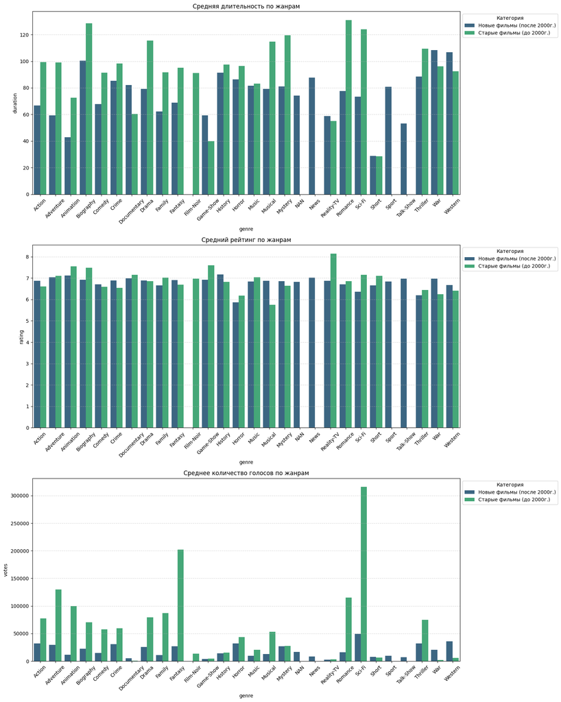

```python
# Создаем копию DataFrame
data_copy = data.copy()

# Функция для извлечения первого года
def extract_year(year):
    if not year or year == 'NAN':  # Если строка пуста или 'NAN', возвращаем NaN
        return np.nan
    year = re.sub('[^0-9–]', '', year)  # Убираем все символы, кроме цифр и тире
    years = year.split('–')  # Разделяем по тире
    return int(years[0]) if years[0] else np.nan  # Берем первый год, если он есть

# Заполняем пропуски в данных
data_copy.fillna('NAN', inplace=True)

# Преобразуем год в числовое значение
data_copy['year'] = data_copy['year'].apply(extract_year)

# Создаем категорию 'old' или 'new' в зависимости от года
data_copy['category'] = data_copy['year'].apply(lambda x: 'old' if x < 2000 else 'new')

# Разделяем жанры на отдельные значения и приводим к DataFrame
data_copy['genre'] = data_copy['genre'].apply(lambda x: x.split(', ') if isinstance(x, str) else [])

# Создаем DataFrame для каждого жанра
genre_data_copy = data_copy.explode('genre')

# Агрегируем данные по жанру и категории (старые/новые фильмы)
aggregated_data_copy = genre_data_copy.groupby(['genre', 'category']).agg({
    'duration': 'mean',
    'rating': 'mean',
    'votes': 'mean'
}).reset_index()



# Визуализация
plt.figure(figsize=(16, 20))

# Средняя длительность фильма по жанрам для старых и новых фильмов
plt.subplot(3, 1, 1)
sns.barplot(x='genre', y='duration', hue='category', data=aggregated_data_copy, palette='viridis')
plt.title('Средняя длительность по жанрам')
plt.xticks(rotation=45)
plt.grid(axis='y', linestyle='--', alpha=0.5)  # Пунктирные линии для оси Y
# Ручная настройка легенды с поясняющими подписями
handles, labels = plt.gca().get_legend_handles_labels()
# Меняем подписи на более подробные
labels = ['Новые фильмы (после 2000г.)', 'Старые фильмы (до 2000г.)']
plt.legend(handles=handles, labels=labels, title='Категория', loc='upper left', bbox_to_anchor=(1, 1))

# Средний рейтинг по жанрам для старых и новых фильмов
plt.subplot(3, 1, 2)
sns.barplot(x='genre', y='rating', hue='category', data=aggregated_data_copy, palette='viridis')
plt.title('Средний рейтинг по жанрам')
plt.xticks(rotation=45)
plt.grid(axis='y', linestyle='--', alpha=0.5)  # Пунктирные линии для оси Y
# Ручная настройка легенды с поясняющими подписями
handles, labels = plt.gca().get_legend_handles_labels()
# Меняем подписи на более подробные
labels = ['Новые фильмы (после 2000г.)', 'Старые фильмы (до 2000г.)']
plt.legend(handles=handles, labels=labels, title='Категория', loc='upper left', bbox_to_anchor=(1, 1))

# Среднее количество голосов по жанрам для старых и новых фильмов
plt.subplot(3, 1, 3)
sns.barplot(x='genre', y='votes', hue='category', data=aggregated_data_copy, palette='viridis')
plt.title('Среднее количество голосов по жанрам')
plt.xticks(rotation=45)
plt.grid(axis='y', linestyle='--', alpha=0.5)  # Пунктирные линии для оси Y
# Ручная настройка легенды с поясняющими подписями
handles, labels = plt.gca().get_legend_handles_labels()
# Меняем подписи на более подробные
labels = ['Новые фильмы (после 2000г.)', 'Старые фильмы (до 2000г.)']
plt.legend(handles=handles, labels=labels, title='Категория', loc='upper left', bbox_to_anchor=(1, 1))

plt.tight_layout()
plt.show()
```

Как видно из столбчатых диаграмм, некоторые жанры отсутствуют до 2000 года (старые), к примеру жанр News - новости, что скорее всего логично в связи того что активная цифровизация и телевидение началось только после 2000 года.

Наибольшую среднюю продолжительность имеют фильмы в жанрах Биография (Biography), Романтика (Romance) и Научная фантастика (Sci-Fi). Наименьшую Короткометражки (Short), что логично :).

Анализ по третьему графику имеет смысл проводить только в особых случаях, так как данный признак содержит просмотры и мнения зрителей только с платформы IMDb.

```python
# построим сводную таблицу (summary statistics) по всем столбцам датафрейма
genre_data_copy.describe(include='all')
```

|  | title | year | certificate | duration | genre | rating | description | stars | votes | category |
| --- | --- | --- | --- | --- | --- | --- | --- | --- | --- | --- |
| count | 22109 | 2.090800e+04 | 22109 | 22109.000000 | 22109 | 22109.000000 | 22109 | 22109 | 2.210900e+04 | 22109 |
| unique | 7912 | NaN | 20 | NaN | 28 | NaN | 9433 | 8615 | NaN | 2 |
| top | Top Gear | NaN | TV-MA | NaN | Drama | NaN | Add a Plot | [] | NaN | new |
| freq | 276 | NaN | 12348 | NaN | 4194 | NaN | 714 | 710 | NaN | 21534 |
| mean | NaN | 3.863828e+06 | NaN | 73.198381 | NaN | 6.822686 | NaN | NaN | 2.278482e+04 | NaN |
| std | NaN | 7.927747e+06 | NaN | 47.364584 | NaN | 1.143794 | NaN | NaN | 9.195783e+04 | NaN |
| min | NaN | 1.932000e+03 | NaN | 1.000000 | NaN | 1.700000 | NaN | NaN | 5.000000e+00 | NaN |
| 25% | NaN | 2.016000e+03 | NaN | 44.000000 | NaN | 6.200000 | NaN | NaN | 4.120000e+02 | NaN |
| 50% | NaN | 2.019000e+03 | NaN | 74.000000 | NaN | 6.800000 | NaN | NaN | 2.045000e+03 | NaN |
| 75% | NaN | 2.022000e+03 | NaN | 94.000000 | NaN | 7.600000 | NaN | NaN | 1.725700e+04 | NaN |
| max | NaN | 2.021202e+07 | NaN | 990.000000 | NaN | 9.900000 | NaN | NaN | 1.844075e+06 | NaN |

```python
genre_data_copy['genre'].value_counts()
```

| genre | count |
| --- | --- |
| Drama | 4194 |
| Comedy | 3098 |
| Action | 1969 |
| Adventure | 1563 |
| Crime | 1491 |
| Animation | 1434 |
| Documentary | 1349 |
| Romance | 1007 |
| Thriller | 889 |
| Mystery | 768 |
| Fantasy | 555 |
| Horror | 530 |
| Family | 493 |
| Reality-TV | 456 |
| History | 415 |
| Biography | 390 |
| Short | 351 |
| Sci-Fi | 293 |
| Music | 236 |
| Sport | 188 |
| Game-Show | 86 |
| Musical | 84 |
| War | 73 |
| NAN | 73 |
| Talk-Show | 55 |
| Western | 34 |
| News | 23 |
| Film-Noir | 12 |

**dtype:** int64

Как видно, по жанрам датасет также является несбалансированным.

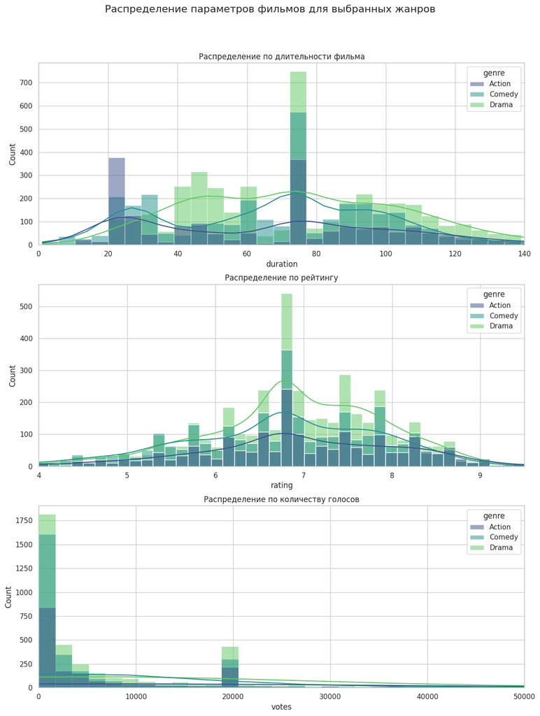

```python
# Установим стиль для графиков библиотеки seaborn
sns.set(style='whitegrid')

# Выбираем 3 жанра для анализа распределений
selected_genres = ['Action', 'Comedy', 'Drama']

# Фильтруем данные, оставляем только выбранные жанры
filtered_data = genre_data_copy[genre_data_copy['genre'].isin(selected_genres)].dropna(subset=['duration', 'rating', 'votes', 'genre'])

# Проверка, что данные не пусты после фильтрации
if filtered_data.empty:
    print("Нет данных для выбранных жанров.")
else:
    # Создание объектов фигуры и оси для 3 параметров
    fig, axs = plt.subplots(3, 1, figsize=(12, 16))

    # Распределение для длительности фильма (duration) по жанрам
    sns.histplot(data=filtered_data, x='duration', kde=True, hue='genre', ax=axs[0], palette='viridis')
    axs[0].set_title('Распределение по длительности фильма')
    axs[0].set_xlim(0, 140)  # Ограничение по длительности, так как много выбросов

    # Распределение для рейтинга (rating) по жанрам
    sns.histplot(data=filtered_data, x='rating', kde=True, hue='genre', ax=axs[1], palette='viridis')
    axs[1].set_title('Распределение по рейтингу')
    axs[1].set_xlim(4, 9.5)  # Ограничение по рейтингу, так как много выбросов

    # Распределение для количества голосов (votes) по жанрам
    sns.histplot(data=filtered_data, x='votes', kde=True, hue='genre', ax=axs[2], palette='viridis')
    axs[2].set_title('Распределение по количеству голосов')
    axs[2].set_xlim(0, 50000)  # Ограничение по количеству голосов, так как много выбросов

    # Визуализация распределений
    fig.suptitle('Распределение параметров фильмов для выбранных жанров', fontsize=16)

    # Устанавливаем общий заголовок
    plt.tight_layout()
    plt.subplots_adjust(top=0.9)

    plt.show()
```

По построенным гистограммам и распределениям (обрезанных, так как имеется множество выбросов, что затрудняет как минимум визуальный анализ, а также были выбраны только 3 жанра для анализа (нетрудно заменить на любые другие интересующие жанры)), можно сделать следующие выводы:

Наибольшее количество фильмов, в рамках таких жанров как Экшен (Action), Комедия (Comedy), Драма (Drama) имеют продолжительность около 75 минут, рейтинг около 6.8, количество зрителей/мнений (IMDb) менее 5000.

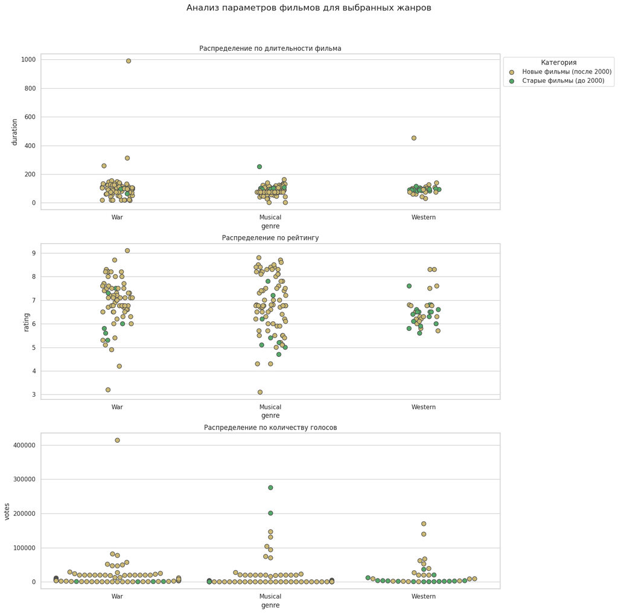

```python
# Установим стиль для графиков библиотеки seaborn
sns.set(style='whitegrid')

# Выбираем 3 жанра для анализа
selected_genres = ['War', 'Western', 'Musical']

# Фильтруем данные, оставляем только выбранные жанры
filtered_data = genre_data_copy[genre_data_copy['genre'].isin(selected_genres)].dropna(subset=['duration', 'rating', 'votes', 'genre'])

# Проверка, что данные не пусты после фильтрации
if filtered_data.empty:
    print("Нет данных для выбранных жанров.")
else:
    # Создание объектов фигуры и оси для 3 параметров
    fig, axs = plt.subplots(3, 1, figsize=(16, 16))

    # Зададим палитру для категорий фильмов (old, new)
    color_palette = {"old": "g", "new": "y"}

    # Распределение для длительности фильма (duration) по жанрам и категориям
    sns.stripplot(data=filtered_data, x='genre', y='duration', hue='category', size=8, edgecolor="gray", palette=color_palette, linewidth=1, ax=axs[0])
    axs[0].set_title('Распределение по длительности фильма')
    # Настройка легенды
    axs[0].legend(title='Категория', loc='upper left', bbox_to_anchor=(1, 1), labels=['Новые фильмы (после 2000)', 'Старые фильмы (до 2000)'])

    # Распределение для рейтинга (rating) по жанрам и категориям
    sns.stripplot(data=filtered_data, x='genre', y='rating', hue='category', size=8, edgecolor="gray", palette=color_palette, linewidth=1, ax=axs[1])
    axs[1].set_title('Распределение по рейтингу')
    # Убираем легенду на втором графике
    axs[1].get_legend().set_visible(False)

    # Распределение для количества голосов (votes) по жанрам и категориям
    sns.swarmplot(data=filtered_data, x='genre', y='votes', hue='category', size=8, edgecolor="gray", palette=color_palette, linewidth=1, ax=axs[2])
    axs[2].set_title('Распределение по количеству голосов')
    # Убираем легенду на третьем графике
    axs[2].get_legend().set_visible(False)

    # Устанавливаем общий заголовок
    fig.suptitle('Анализ параметров фильмов для выбранных жанров', fontsize=16)

    # Устанавливаем настройки макета
    plt.tight_layout()
    plt.subplots_adjust(top=0.9)

    # Показываем графики
    plt.show()
```

Здесь можно увидеть как разбросаны фильмы по длительности, рейтингу и количеству оценок. К примеру, в рамках выбранных 3-х жанров (Военные (War), Музыкальные (Musical), Вестерн (Western)):

- по длительности: старые и новые фильмы образуются в "кучи" до 200 минут, имеются выбросы, что скорее всего говорит о наличии сериалов, к примеру для жанра Военные (War) ниже будет найден образец-выброс с длительностью 990 минут, который оказался сериалом.
- по рейтингу: старые и новые во всех жанрах имеют большой разброс по оценкам, кроме может жанра Вестерн (Western), который более менее сгруппирован в примерном диапазоне оценок от 5.6 до 8.2.
- по количестуву оценок (IMDb): большинство фильмов имеют низкое количество оценок и мнений, также имеются выбросы - к примеру, у жанра Военные (War) имеется фильм с количеством оценок более чем 400 000.

```python
# Найдём строки с жанром 'War' и длительностью более 900 минут
outliers = filtered_data[(filtered_data['genre'] == 'War') & (filtered_data['duration'] > 900)]
pd.set_option('display.max_columns', None)  # Показывать все столбцы
# Выводим найденные строки
print(outliers)
```

```
               title    year certificate  duration genre  rating  \
943  The Vietnam War  2017.0       TV-MA       990   War     9.1

                                           description  \
943  A comprehensive history of the United States' ...

                                                 stars  votes category
943  ['Peter Coyote, ', 'Huy Duc, ', 'James Willban...  24632      new
```

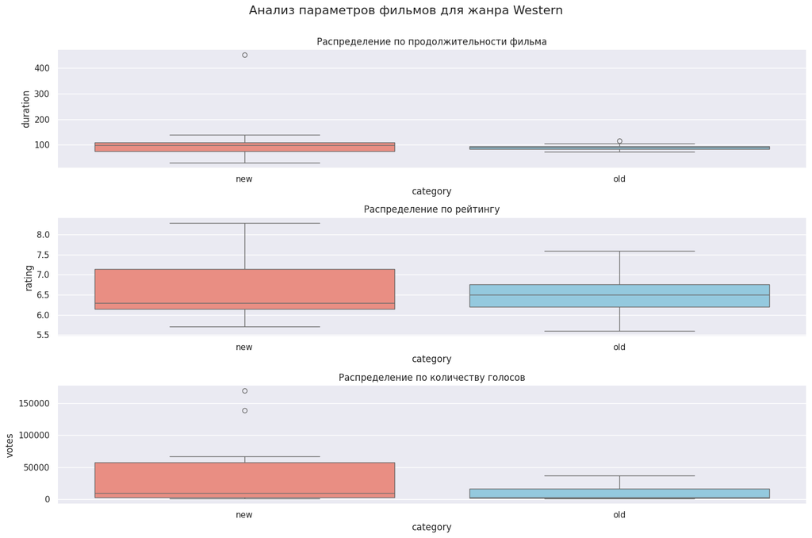

```python
# Установим стиль для графиков библиотеки seaborn
sns.set(style='darkgrid')

# Выбираем жанры для анализа
selected_genre = 'Western'  # Пример жанра

# Применим фильтрацию данных для выбранного жанра и разделим на старые и новые фильмы
filtered_data = genre_data_copy[(genre_data_copy['genre'] == selected_genre)].copy()

# Разделим фильмы на новые и старые
filtered_data['category'] = ['new' if year >= 2000 else 'old' for year in filtered_data['year']]

# Создание объектов фигуры и оси для 2 графиков
fig, axs = plt.subplots(3, 1, figsize=(15, 10))

# Установим палитру
palette = {"old": "skyblue", "new": "salmon"}

# Построим распределение продолжительности фильма и рейтинга
sns.boxplot(data=filtered_data, x='category', y='duration', ax=axs[0], palette=palette)
sns.boxplot(data=filtered_data, x='category', y='rating', ax=axs[1], palette=palette)
sns.boxplot(data=filtered_data, x='category', y='votes', ax=axs[2], palette=palette)

# Установим названия для графиков
axs[0].set_title('Распределение по продолжительности фильма')
axs[1].set_title('Распределение по рейтингу')
axs[2].set_title('Распределение по количеству голосов')

# Установим общий заголовок
fig.suptitle(f'Анализ параметров фильмов для жанра {selected_genre}', fontsize=16)

# Нарисуем графики
plt.tight_layout()
plt.subplots_adjust(top=0.9)  # Отодвинем верхнюю панель для общего заголовка
plt.show()
```

Данный график - boxplot, показывает распределение числовой перемнной, только в рамках одного выбранного жанра Вестерн (Western). А также на каждом ящике с усами имеется горизонтальная черная линия, которая является медианой. К примеру, рейтинг у Вестерн (Western) старых фильмов ниже оценки 6.5 имеют 50% фильмов по этому жанру, и 50% фильмов имеют оценки выше этого значения.

```python
# Создаем копию датасета
data_year_cleaned = data.copy()

# Удаляем пропуски, оставляя только строки с непустым годом
data_year_cleaned = data_year_cleaned[~data_year_cleaned['year'].isna()].copy()

# Извлекаем первый год из строки (даже если их два через пробел)
data_year_cleaned['year'] = data_year_cleaned['year'].str.extract(r'(\d{4})').astype(float)

# Удалим строки с отсутствующим годом
data_year_cleaned = data_year_cleaned.dropna(subset=['year'])

# Преобразуем к int, теперь безопасно
data_year_cleaned['year'] = data_year_cleaned['year'].astype(int)
```

```python
# Создаем категорию 'old' или 'new' в зависимости от года
data_year_cleaned['category'] = data_year_cleaned['year'].apply(lambda x: 'old' if x < 2000 else 'new')

# Разделяем жанры на отдельные значения и приводим к DataFrame
data_year_cleaned['genre'] = data_year_cleaned['genre'].apply(lambda x: x.split(', ') if isinstance(x, str) else [])

# Создаем DataFrame для каждого жанра
genre_data_year_cleaned = data_year_cleaned.explode('genre')
```

```python
genre_data_year_cleaned.info()
```

```
<class 'pandas.core.frame.DataFrame'>
Index: 20908 entries, 0 to 9956
Data columns (total 10 columns):
 #   Column       Non-Null Count  Dtype
---  ------       --------------  -----
 0   title        20908 non-null  object
 1   year         20908 non-null  int64
 2   certificate  20908 non-null  object
 3   duration     20908 non-null  int64
 4   genre        20908 non-null  object
 5   rating       20908 non-null  float64
 6   description  20908 non-null  object
 7   stars        20908 non-null  object
 8   votes        20908 non-null  int64
 9   category     20908 non-null  object
dtypes: float64(1), int64(3), object(6)
memory usage: 1.8+ MB
```

```python
# Посмотрим все уникальные жанры имеющиеся в нашем датасете
print(genre_data_year_cleaned['genre'].unique())
```

```
['Action' 'Comedy' 'Drama' 'Biography' 'History' 'Crime' 'Horror'
 'Mystery' 'Animation' 'Adventure' 'Fantasy' 'Thriller' 'Romance' 'Sport'
 'Sci-Fi' 'Family' 'Short' 'Documentary' 'War' 'Music' 'Reality-TV'
 'Musical' 'Western' 'Game-Show' 'Talk-Show' 'Film-Noir' 'News' 'NAN']
```

```python
# Группируем по жанру и году, считаем среднее по интересующим параметрам
agg_by_year_genre = genre_data_year_cleaned.groupby(['genre', 'year']).agg({
    'rating': 'mean',
    'duration': 'mean',
    'votes': 'mean',
    'title': 'count'  # сколько фильмов в этом жанре в этом году
}).rename(columns={'title': 'count'}).reset_index()
```

```python
# выведем 10 случайных строк из полученной группировке данных
agg_by_year_genre.sample(10)
```

|  | genre | year | rating | duration | votes | count |
| --- | --- | --- | --- | --- | --- | --- |
| 459 | Fantasy | 1975 | 8.200000 | 91.000000 | 538546.000000 | 1 |
| 66 | Adventure | 1978 | 6.600000 | 103.000000 | 39841.500000 | 2 |
| 546 | Horror | 1995 | 7.600000 | 22.000000 | 13649.000000 | 1 |
| 274 | Crime | 1984 | 7.100000 | 50.000000 | 24323.000000 | 1 |
| 69 | Adventure | 1984 | 7.250000 | 64.000000 | 87008.500000 | 2 |
| 833 | Thriller | 1969 | 6.600000 | 108.000000 | 2356.000000 | 1 |
| 735 | Romance | 2009 | 7.133333 | 71.666667 | 120068.666667 | 9 |
| 870 | War | 1963 | 5.800000 | 95.000000 | 274.000000 | 1 |
| 681 | News | 2015 | 7.350000 | 73.500000 | 4965.000000 | 2 |
| 291 | Crime | 2006 | 8.357576 | 64.969697 | 87591.515152 | 33 |

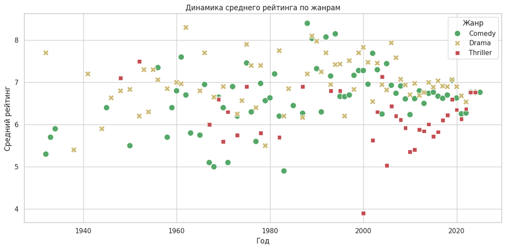

```python
# Выберем несколько популярных жанров для сравнения
selected_genres = ['Comedy', 'Drama', 'Thriller']

# Фильтруем агрегированные данные
filtered = agg_by_year_genre[agg_by_year_genre['genre'].isin(selected_genres)]

# Цвета для жанров
cmap = {
    'Comedy': 'g',
    'Drama': 'y',
    'Thriller': 'r'
}

# График: рейтинг по годам
plt.figure(figsize=(12, 6))
sns.set_style('whitegrid')

sns.scatterplot(
    data=filtered,
    x='year',
    y='rating',
    hue='genre',
    style='genre',
    palette=cmap,
    s=100
)

plt.title('Динамика среднего рейтинга по жанрам')
plt.xlabel('Год')
plt.ylabel('Средний рейтинг')
plt.legend(title='Жанр')
plt.tight_layout()
plt.show()
```

Данный тип графика показывает динамику среднего рейтинга в рамках выбранных жанров (Комедия (Comedy), Драма (Drama), Триллер (Thriller)). Из точеченого графика, трудно рассмотреть тренд, вроде как всё стабильно с каждым годом, что наверное хорошо. Можно увидеть что точек становится больше с каждым годом - фильмов выпускается больше.

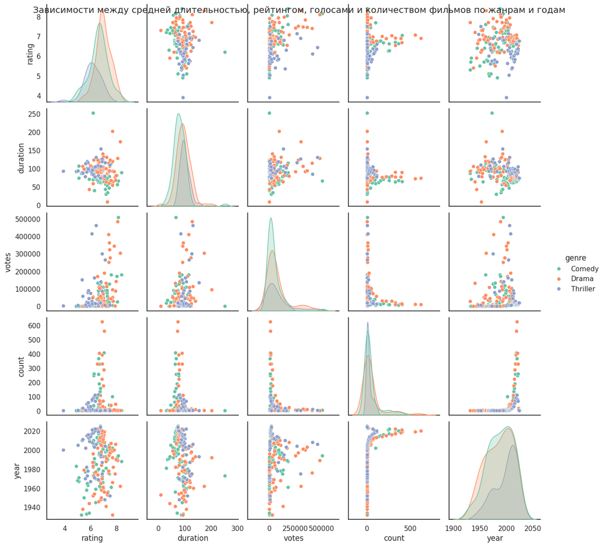

```python
# Построим pairplot
sns.set_style('white')
sns.pairplot(
    data=filtered,
    vars=['rating', 'duration', 'votes', 'count', 'year'],
    hue='genre',
    palette='Set2'
    )
plt.suptitle('Зависимости между средней длительностью, рейтингом, голосами и количеством фильмов по жанрам и годам')
plt.show()
```

Этот график имеет уже множество подграфиков, которые показывают зависимости между средней длительностью, рейтингом, голосами и количеством фильмов по жанрам (тем же что и ранее выбраным) и годам.

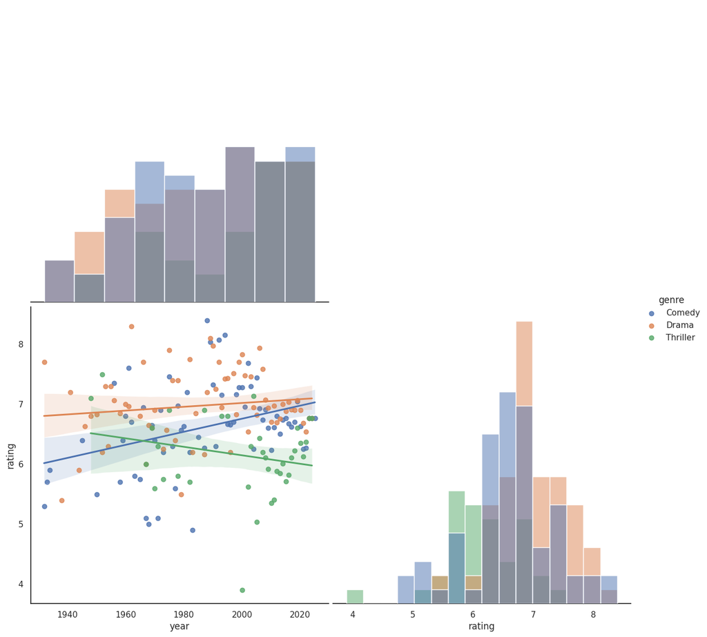

```python
sns.set_style(style='white')
sns.pairplot(
    data=filtered,
    hue='genre',
    kind='reg',
    diag_kind='hist',
    vars=["year", "rating"],
    corner=True,
    height=6
)
```

Здесь помимо точек на графике построенны линейные регрессии, которые показывают направление тренда, если ранее по точкам было трудно что-либо разглядеть, то сейчас видно что по жанрам Комедия (Comedy) и Драма (Drama) с течением времени имеется небольшой рост по рейтингу, а по Триллерам (Thriller) спад.

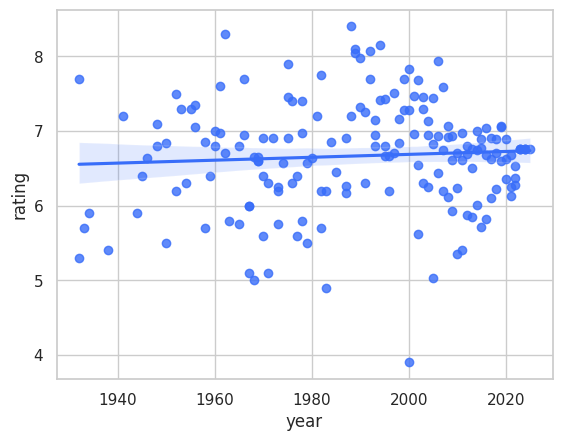

```python
sns.set_palette('rainbow')
sns.set_style("whitegrid")

sns.regplot(x="year", y="rating", data=filtered)
```

Здесь также показан тренд, но только общий для всех трех жанров выбранных, имеется небольшой рост рейтинга с течением лет.

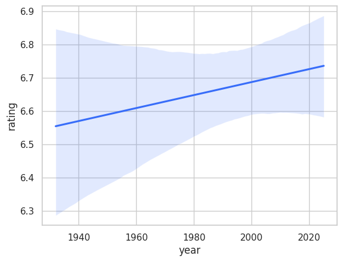

```python
sns.regplot(x="year", y="rating", scatter=False, data=filtered)
```

Отображая только линию тренда можно точнее увидеть её направление и диапазон оценки фильмов. В рамках заданных трех жанров, имеется рост рейтинга с течением лет примерно с 6.56 до 6.73

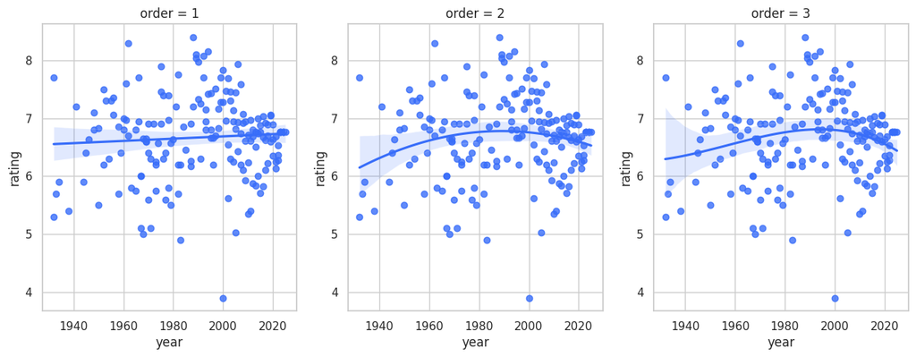

```python
order=[1, 2, 3]
plt.figure(figsize=(15, 5))
for i, o in enumerate(order):
 plt.subplot(1, len(order), i+1)
 plt.title(f"order = {o}")
 sns.regplot(x="year", y="rating", order=o, data=filtered)
```

Здесь показаны регрессионные кривые разных степеней.

- order=1 покажет общую линейную тенденцию (например, растёт или падает).
- order=2 покажет наличие "яма/горб" — возможно, рейтинги сначала росли, потом падали.
- order=3 покажет сложные тренды — например, рост, потом спад, потом снова рост.

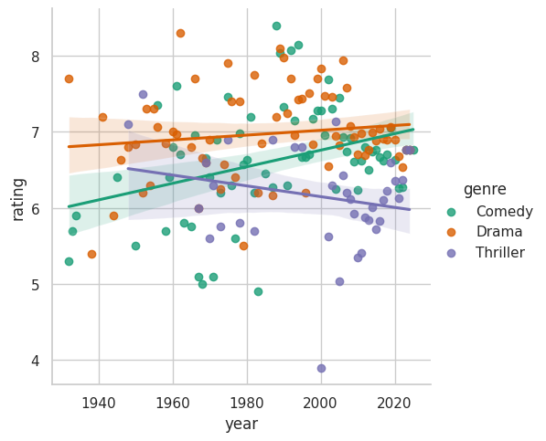

```python
sns.lmplot(x="year", y="rating", hue="genre", palette="Dark2", data=filtered)
```

Здесь идет дублирование ранее построенных графиков, только с помощью другой функции.

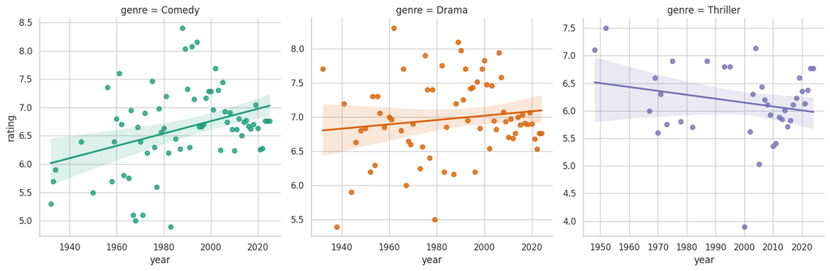

```python
sns.lmplot(x="year", y="rating", palette="Dark2", hue="genre", col="genre",
           facet_kws={'sharex':False, 'sharey':False}, data=filtered)
```

Здесь идет дублирование ранее построенных графиков, только с помощью другой функции, а также в разных окнах с разынм масштабированием, что бывает удобнее для анализа.

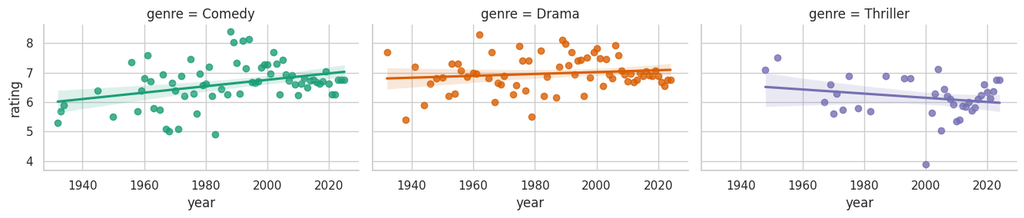

```python
# Для управления размером диаграмм используйте параметры height (высота) и aspect (соотношение сторон):
sns.lmplot(x="year", y="rating", hue="genre", palette="Dark2", col="genre", height=3, aspect=1.5, data=filtered)
```

Здесь показаны возможность изменять масштабирование как нам будет удобно.

```python
# для выбранных ранее трех жанров отфильтруем их по категории new и old
filtered_with_category = filtered.copy()
filtered_with_category['category'] = filtered_with_category['year'].apply(lambda x: 'old' if x < 2000 else 'new')
```

```python
filtered_with_category.sample(5)
```

|  | genre | year | rating | duration | votes | count | category |
| --- | --- | --- | --- | --- | --- | --- | --- |
| 363 | Drama | 1965 | 6.800000 | 101.000000 | 2552.000000 | 1 | old |
| 412 | Drama | 2020 | 6.898033 | 73.900800 | 9804.011200 | 625 | new |
| 187 | Comedy | 1961 | 7.600000 | 115.000000 | 180040.000000 | 1 | old |
| 395 | Drama | 2003 | 7.455556 | 94.333333 | 363229.444444 | 9 | new |
| 407 | Drama | 2015 | 6.886036 | 77.855856 | 29445.216216 | 222 | new |

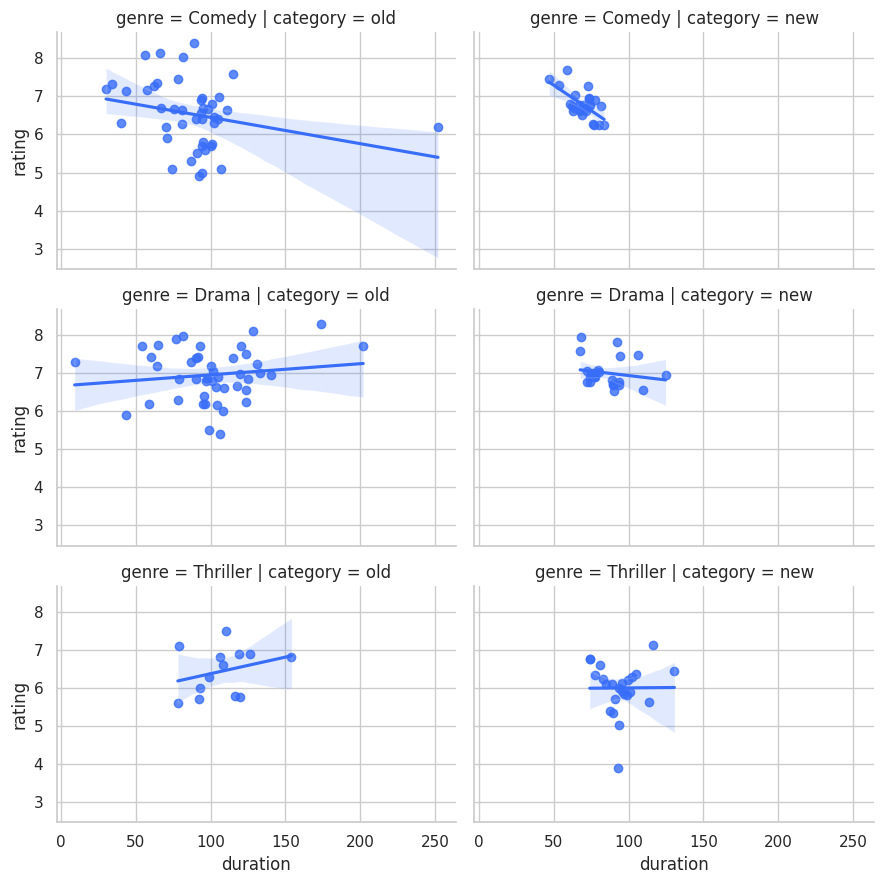

```python
sns.lmplot(x="duration", y="rating", palette="bright",
           col="category", row ='genre', height=3, aspect=1.5, data=filtered_with_category)
```

Здесь показаны точечные графики с трендами - по столбцам графики разделены на категории фильмов new и old, по строкам разделены на ранее выбранные 3 жанра, по ячейкам мы получаем отображение объединенных данных по двум признакам и смотрим тенденцию их рейтингов.

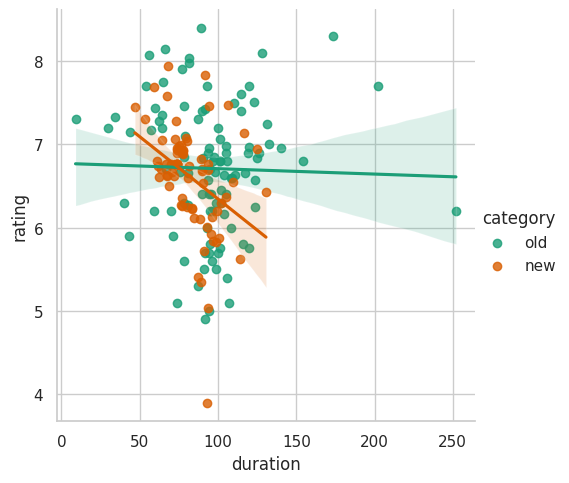

```python
sns.lmplot(x="duration", y="rating", hue="category", palette="Dark2", data=filtered_with_category)
```

Здесь построен точечный график для старых и новых фильмов по трем ранее выбранным жанрам, анализируемый тренд - зависимость между длительностью фильмов и их рейтингами. Как видно из графика для новых фильмов чем их длительность больше, тем ниже оценка, для старых фильмов это слабо выражено, но также спад оценки с ростом длительности.

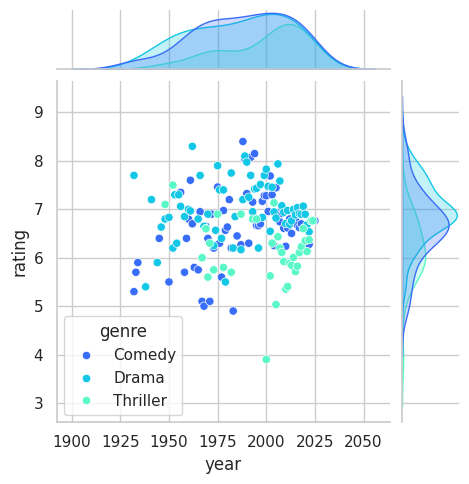

```python
sns.jointplot(x="year", y="rating", hue="genre", height=5, data=filtered)
```

Данный тип графика строит следующее:

- в центре — 2D график зависимости x и y;
- по краям — односторонние распределения по x и y. По поводу зависимостей сказано было всё раньше и описано. А здесь, по умолчанию строится kind="scatter" (точки), ниже предлагается данный параметр менять.

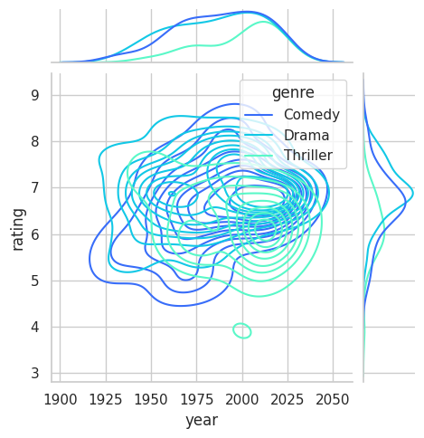

```python
sns.jointplot(data=filtered, x="year", y="rating", hue="genre", height=5, kind="kde")
```

kind="kde" — плотности. Показывает, где концентрируются данные, а не отдельные точки.

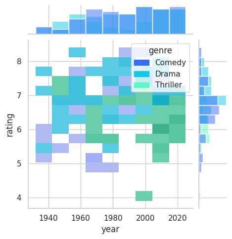

```python
sns.jointplot(data=filtered, x="year", y="rating", hue="genre", height=5, kind="hist")
```

kind="hist" — двумерная гистограмма. Показывает: частоту попадания точек в диапазоны (биновая сетка).

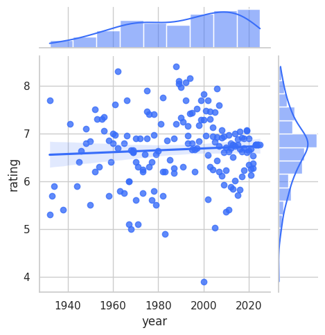

```python
sns.jointplot(data=filtered, x="year", y="rating", height=5, kind="reg")
```

kind="reg" — регрессия. Центр: scatter plot + регрессионная прямая (с доверительным интервалом).

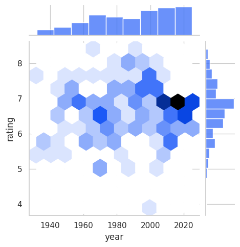

```python
sns.jointplot(data=filtered, x="year", y="rating", height=5, kind="hex")
```

kind="hex" — шестиугольники. Похоже на hist, но вместо квадратов — шестиугольники.

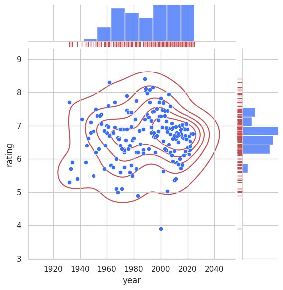

```python
g = sns.jointplot(data=filtered, x="year", y="rating")
g.plot_joint(sns.kdeplot, color="r", zorder=0, levels=6)
g.plot_marginals(sns.rugplot, color="r", height=-.15, clip_on=False)
```

Центр: kde-контуры поверх точек.

Края: rugplot — маленькие черточки, показывающие каждое значение.

Комбинирует визуализации — позволяет сравнивать разные аспекты данных.

```python
# построим для числовых признаков корреляционную матрицу Пирсона
data_year_cleaned.corr(method='pearson', numeric_only=True)
```

|  | year | duration | rating | votes |
| --- | --- | --- | --- | --- |
| year | 1.000000 | -0.013359 | -0.065803 | -0.142258 |
| duration | -0.013359 | 1.000000 | -0.155888 | 0.106329 |
| rating | -0.065803 | -0.155888 | 1.000000 | 0.142622 |
| votes | -0.142258 | 0.106329 | 0.142622 | 1.000000 |

Просто числовой вывод, без визуализации.

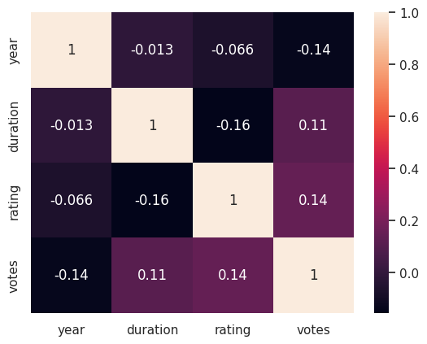

```python
# Данная функция графически визуализирует корреляционную матрицу
sns.heatmap(data_year_cleaned.corr(method='pearson', numeric_only=True),annot = True)
```

Позволяет быстро увидеть:

- где есть сильные связи,
- где переменные слабо или отрицательно коррелируют.

Для наших признаков, все имеют друг с другом очень слабую связь.

```python
fig = px.scatter_3d(filtered, x='year', y='rating', z='duration',
              color='genre', opacity=0.7)
fig.update_layout(margin=dict(l=0, r=0, b=0, t=0))
fig.show()
```

[interactive chart not shown]

Этот график создаёт 3D-распределение фильмов по трём признакам для трех ранее заданных жанров. Ось X — год выпуска фильма. Ось Y — рейтинг фильма. Ось Z — длительность фильма. Цвет — жанр фильма.

Особых кластеров не наблюдается.